# Weight Lifting Manner Prediction Project

Tri Le

May 2015

## Introduction

The goal of this project is to predict the manner (class) in which people did the weight lifting exercise. The following tasks are performed to achieve the goal: getting and cleaning data, performing exploratory data analysis, using cross validation for final model selection, building several predictive models, and predicting 20 different test cases using the selected model.

The data set for this project was collected from the accelerometers worn on the belt, forearm, arm, and dumbell of six young healthy participants. These six participants were asked to perform one set of 10 repetitions of the Unilateral Dumbbell Biceps Curl in five different fashions: exactly according to the specification (Class A), throwing the elbows to the front (Class B), lifting the dumbbell only halfway (Class C), lowering the dumbbell only halfway (Class D) and throwing the hips to the front (Class E). Class A corresponds to the specified execution of the exercise, while the other 4 classes correspond to common mistakes. These classes are levels of the “classe” variable in the training set.

## Get data

The data for this project come from this source: http://groupware.les.inf.puc-rio.br/har.

```r
# get data
if(!file.exists("pml-training.csv"))
        download.file(url="https://d396qusza40orc.cloudfront.net/predmachlearn/pml-training.csv",destfile="pml-training.csv",method="curl")
if(!file.exists("pml-testing.csv"))
        download.file(url="https://d396qusza40orc.cloudfront.net/predmachlearn/pml-testing.csv",destfile="pml-testing.csv",method="curl")
training <- read.csv("pml-training.csv", na.strings=c("NA", "#DIV/0!", ""))
testing <- read.csv("pml-testing.csv", na.strings=c("NA", "#DIV/0!", ""))
```

## Clean data

Get the original dimension of the training data set.

```r
dim(training)
```

```
## [1] 19622   160
```

The first 6 variables carry no information about the manners of weight lifting exercise. So, they are removed.

```r
# first 6 variables
names(training[1:6])
```

```
## [1] "X"                    "user_name"            "raw_timestamp_part_1"
## [4] "raw_timestamp_part_2" "cvtd_timestamp"       "new_window"
```

```r
# remove the first 6 variables
training <- training[,7:160]
testing <- testing[,7:160]
```

In the summary of the training data set, there are a lot of variables which have more than 19200 missing data out of 19622 observations (98% missing data), so these variables are removed as well.

```r
# remove variables with missing data
no.na <- (apply(is.na(training), 2, sum) == 0)
training <- training[, no.na]
testing <- testing[, no.na]
```

## Exploratory data analysis

Get the new dimension of the training data set after cleaning.

```r
dim(training)
```

```
## [1] 19622    54
```

The new dimension above, with the number of features p much smaller than the number of observation N (p << N), shows that this training data set does not have high dimensional problem (p >> N), so less prone to overfitting.

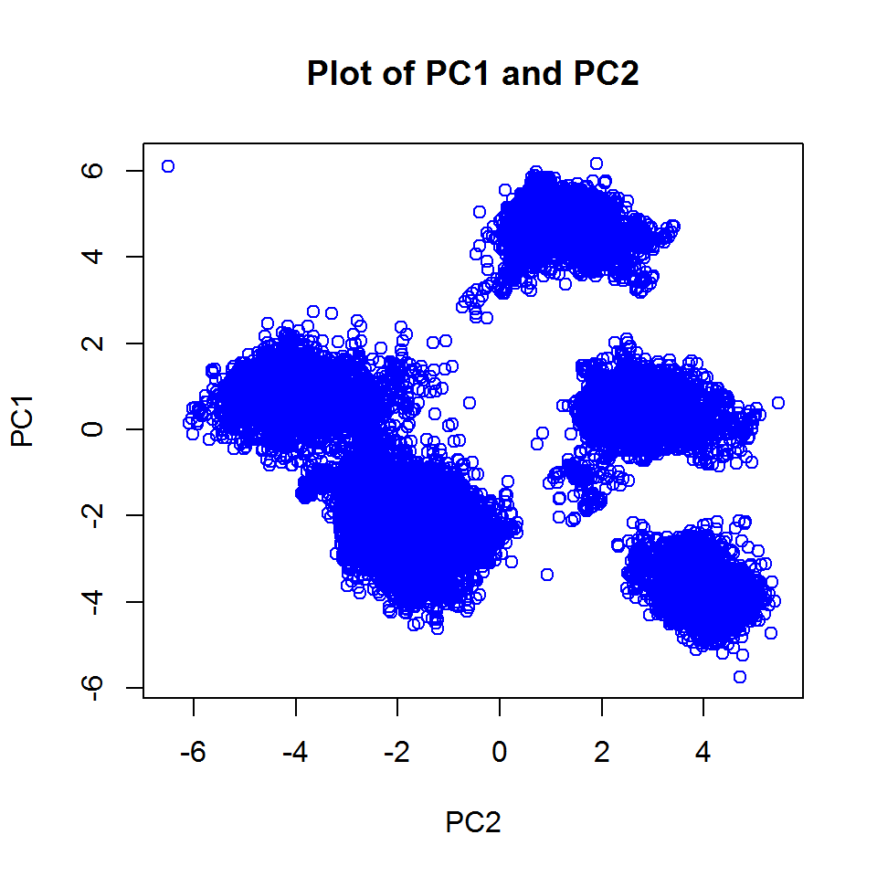

```r
# use PCA to visualize data only
plotdata <- data.frame(apply(training, 2, as.numeric))
plotdata <- plotdata[,-54]
preProc <- preProcess(plotdata, method="pca", pcaComp=2, na.remove=TRUE)
# create new PC variables
dataPC <- predict(preProc, plotdata)
# plot PCs
plot(dataPC[,1], dataPC[,2], col="blue", main="Plot of PC1 and PC2", ylab="PC1", xlab="PC2")
```

In the scatter plot above, all the data points concentrate and form five distinctive groups which likely are five classes (manners) of the weight lifting exercise. There’s only one data point on the far upper left corner, so it could be neglectible.

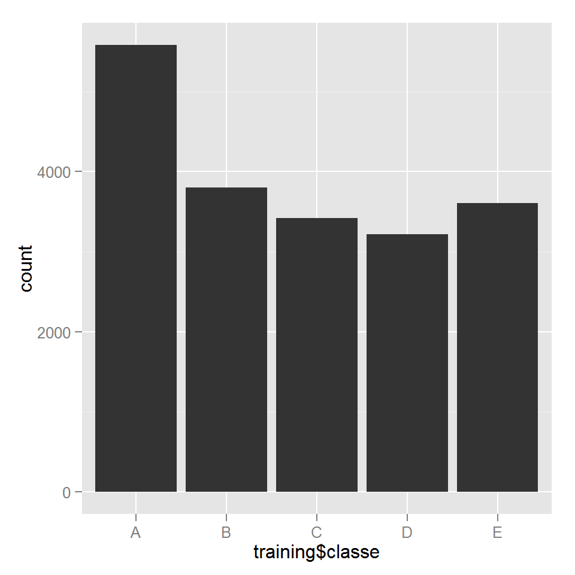

```r
qplot(training$classe)
```

The histogram above shows that class A has more counts than the other but overall all classes are balanced.

From data visualization, we can say that this training data set looks good.

## Split training data set for cross validation

Training data is splitted for cross validation with 70% data for sub training data set and 30% for sub cross validation data set.

```r
# split training data for cross validation
set.seed(1513)
trainIndex <- createDataPartition(training$classe, p = 0.7, list = FALSE)
train.set <- training[trainIndex,]
cv.set <- training[-trainIndex,]
```

## Build predictive models

Three models constructed and tuned are K-Nearest Neighbor, Gradient Boosted Machine, and Random Forests. Each model is automatically tuned and evaluated using 5-fold cross validation to estimate accuracy for model selection. Note that both 5-fold and 10-fold were tried out and we saw that there’s very little difference in the accuracy between two of them. Therefore, 5-fold is selected for shorter training time (little bit more bias, little bit less variance). The set.seed function is used for each model for reproductivity.

```r
# define training control
control <- trainControl(method="cv", number=5)
```

### Model 1: K-Nearest Neighbor

The K-Nearest Neighbor algorithm (KNN) is a method for classifying objects based on the closest training examples in the feature space. KNN is a type of instance-based learning, or lazy learning where the function is only approximated locally and all computation is deferred until classification. The KNN algorithm is amongst the simplest of all machine learning algorithms: an object is classified by a majority vote of its neighbors, with the object being assigned to the class most common amongst its k nearest neighbors (k is a positive integer, typically small).

```r
# knn model
set.seed(1513)
knn.fit <- train(classe ~ ., data=train.set, method="knn", trControl=control)
confusionMatrix(cv.set$classe, predict(knn.fit, cv.set))
```

```
## Confusion Matrix and Statistics
##
##           Reference
## Prediction    A    B    C    D    E
##          A 1616   18   20   16    4
##          B   53  985   41   38   22
##          C   12   36  941   28    9
##          D   14    9   71  846   24
##          E    9   22   16   46  989
##
## Overall Statistics
##
##                Accuracy : 0.9137
##                  95% CI : (0.9062, 0.9207)
##     No Information Rate : 0.2895
##     P-Value [Acc > NIR] : < 2.2e-16
##
##                   Kappa : 0.8908
##  Mcnemar's Test P-Value : 1.619e-10
##
## Statistics by Class:
##
##                      Class: A Class: B Class: C Class: D Class: E
## Sensitivity            0.9484   0.9206   0.8641   0.8686   0.9437
## Specificity            0.9861   0.9680   0.9823   0.9760   0.9808
## Pos Pred Value         0.9654   0.8648   0.9172   0.8776   0.9140
## Neg Pred Value         0.9791   0.9821   0.9695   0.9740   0.9877
## Prevalence             0.2895   0.1818   0.1850   0.1655   0.1781
## Detection Rate         0.2746   0.1674   0.1599   0.1438   0.1681
## Detection Prevalence   0.2845   0.1935   0.1743   0.1638   0.1839
## Balanced Accuracy      0.9672   0.9443   0.9232   0.9223   0.9622
```

### Model 2: Gradient Boosted Machine

In gradient boosting machine(GBM), the learning procedure consecutively fits new models to provide a more accurate estimate of the response variable. The principle idea behind this algorithm is to construct the new base-learners to be maximally correlated with the negative gradient of the loss function, associated with the whole ensemble. The loss functions applied can be arbitrary, but to give a better intuition, if the error function is the classic squared-error loss, the learning procedure would result in consecutive error-fitting.

```r
# gbm model
set.seed(1513)
gbm.fit <- train(classe ~ ., data=train.set, method="gbm", trControl=control, verbose=FALSE)
confusionMatrix(cv.set$classe, predict(gbm.fit, cv.set))
```

```
## Confusion Matrix and Statistics
##
##           Reference
## Prediction    A    B    C    D    E
##          A 1671    3    0    0    0
##          B    2 1114   22    1    0
##          C    0   13 1011    2    0
##          D    3    2   12  947    0
##          E    0   10    1   12 1059
##
## Overall Statistics
##
##                Accuracy : 0.9859
##                  95% CI : (0.9825, 0.9888)
##     No Information Rate : 0.2848
##     P-Value [Acc > NIR] : < 2.2e-16
##
##                   Kappa : 0.9822
##  Mcnemar's Test P-Value : NA
##
## Statistics by Class:
##
##                      Class: A Class: B Class: C Class: D Class: E
## Sensitivity            0.9970   0.9755   0.9665   0.9844   1.0000
## Specificity            0.9993   0.9947   0.9969   0.9965   0.9952
## Pos Pred Value         0.9982   0.9781   0.9854   0.9824   0.9787
## Neg Pred Value         0.9988   0.9941   0.9928   0.9970   1.0000
## Prevalence             0.2848   0.1941   0.1777   0.1635   0.1799
## Detection Rate         0.2839   0.1893   0.1718   0.1609   0.1799
## Detection Prevalence   0.2845   0.1935   0.1743   0.1638   0.1839
## Balanced Accuracy      0.9982   0.9851   0.9817   0.9905   0.9976
```

### Model 3: Random Forests

Random forests (Breiman, 2001) is a substantial modification of bagging that builds a large collection of de-correlated trees, and then averages them. On many problems the performance of random forests is very similar to boosting, and they are simpler to train and tune.

```r
# randomforest model
set.seed(1513)
rf.fit <- train(classe ~ ., data=train.set, method="rf", trControl=control, importance=TRUE)
confusionMatrix(cv.set$classe, predict(rf.fit, cv.set))
```

```
## Confusion Matrix and Statistics
##
##           Reference
## Prediction    A    B    C    D    E
##          A 1674    0    0    0    0
##          B    2 1135    2    0    0
##          C    0    6 1020    0    0
##          D    0    0    3  961    0
##          E    0    2    0    7 1073
##
## Overall Statistics
##
##                Accuracy : 0.9963
##                  95% CI : (0.9943, 0.9977)
##     No Information Rate : 0.2848
##     P-Value [Acc > NIR] : < 2.2e-16
##
##                   Kappa : 0.9953
##  Mcnemar's Test P-Value : NA
##
## Statistics by Class:
##
##                      Class: A Class: B Class: C Class: D Class: E
## Sensitivity            0.9988   0.9930   0.9951   0.9928   1.0000
## Specificity            1.0000   0.9992   0.9988   0.9994   0.9981
## Pos Pred Value         1.0000   0.9965   0.9942   0.9969   0.9917
## Neg Pred Value         0.9995   0.9983   0.9990   0.9986   1.0000
## Prevalence             0.2848   0.1942   0.1742   0.1645   0.1823
## Detection Rate         0.2845   0.1929   0.1733   0.1633   0.1823
## Detection Prevalence   0.2845   0.1935   0.1743   0.1638   0.1839
## Balanced Accuracy      0.9994   0.9961   0.9969   0.9961   0.9991
```

## Model selection

The resamples function is used to compare these three models based on their cross-validation statistics. Since the random number seed was initialized prior to running these models, paired accuracy measurements exist for each data set.

```r
# resample to compare
resamp <- resamples(list(KNN=knn.fit, GBM=gbm.fit, RF=rf.fit))
# summarize
summary(resamp)
```

```
##
## Call:
## summary.resamples(object = resamp)
##
## Models: KNN, GBM, RF
## Number of resamples: 5
##
## Accuracy
##       Min. 1st Qu. Median   Mean 3rd Qu.   Max. NA's
## KNN 0.8980  0.8992 0.9003 0.9002  0.9017 0.9018    0
## GBM 0.9822  0.9865 0.9869 0.9860  0.9873 0.9873    0
## RF  0.9960  0.9964 0.9967 0.9967  0.9971 0.9971    0
##
## Kappa
##       Min. 1st Qu. Median   Mean 3rd Qu.   Max. NA's
## KNN 0.8711  0.8724 0.8738 0.8738  0.8757 0.8758    0
## GBM 0.9774  0.9830 0.9834 0.9823  0.9839 0.9839    0
## RF  0.9949  0.9954 0.9959 0.9958  0.9963 0.9963    0
```

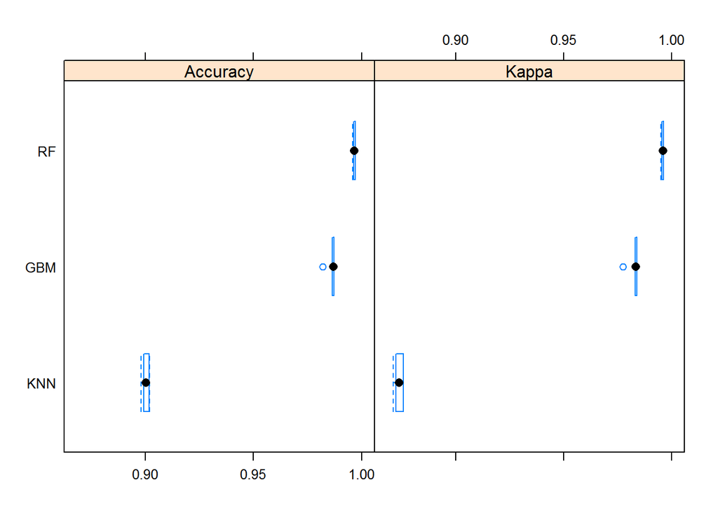

```r
# boxplot
bwplot(resamp)
```

KNN computation time:

```
##    user  system elapsed
##   30.23    0.08   30.31
```

GBM computation time:

```
##    user  system elapsed
##  245.75    0.23  246.06
```

RF computation time:

```
##    user  system elapsed
##  840.30    2.13  842.78
```

### Final model

From the summary, boxplot, and computation time lists, we can see that the Random Forests model has the highest accuracy score which is 0.996. The GBM model has a very good accuracy score too, which is 0.986 (very closed to the RF accuracy score). The GBM model has 3 times shorter computation time (compare to the RF model). But because we have a limit of only 2 times to predict for each test case in this project. So, accuracy score is more important than computation time in this case. Therefore, the Random Forests model is selected as the final model for it’s highest accuracy score.

Below is the list of 20 most important variables of the final model (Random Forests):

```r
# important variables
imp.var <- varImp(rf.fit)
imp.var
```

```
## rf variable importance
##
##   variables are sorted by maximum importance across the classes
##   only 20 most important variables shown (out of 53)
##
##                           A      B     C     D      E
## num_window           62.676 100.00 96.45 61.29 67.755
## roll_belt            61.528  77.52 63.07 71.74 72.760
## pitch_forearm        47.383  58.74 74.13 51.02 46.650
## magnet_dumbbell_z    65.585  51.02 67.41 49.66 42.097
## magnet_dumbbell_y    48.132  51.45 51.84 47.69 40.450
## pitch_belt           21.566  51.82 48.94 35.42 30.335
## yaw_belt             29.730  44.98 47.05 49.82 33.933
## accel_forearm_x      10.909  25.82 19.33 30.85 29.516
## roll_forearm         29.417  22.24 23.19 19.05 20.772
## accel_dumbbell_y     22.642  21.89 28.27 22.11 23.847
## gyros_dumbbell_y     26.919  16.78 23.66 18.00 11.249
## roll_dumbbell        13.440  22.41 17.67 19.72 23.496
## magnet_belt_z        11.292  20.91 13.66 22.31 16.474
## accel_dumbbell_z     14.638  17.97 16.42 21.71 20.235
## total_accel_dumbbell  9.309  19.48 14.49 21.07 19.702
## magnet_forearm_z     20.127  20.56 16.07 20.08 15.583
## magnet_belt_x         5.842  20.42 17.97 13.83 17.464
## roll_arm              9.613  20.26 13.99 17.14  9.985
## magnet_dumbbell_x    15.509  18.55 16.76 19.05 14.805
## magnet_belt_y         8.256  18.49 17.80 14.63 14.178
```

## Predict test cases

The final model (Random Forests) is used to predict 20 different test cases:

```r
rf.pred <- predict(rf.fit, testing)
rf.pred
```

```
##  [1] B A B A A E D B A A B C B A E E A B B B
## Levels: A B C D E
```

## References

Trevor Hastie, Robert Tibshirani, and Jerome Friedman. The Elements of Statistical Learning. 2008.  
Max Kuhn, Kjell Johnson. Applied Predictive Modeling. 2013.  
Andrew Ng. Machine Learning lecture notes.